# Selection on Observables

# Selection on Observables

In this project, we will explore a few techniques utilizing selection on observables in an effort to determine the effect of a treatment on a population. Such tools may prove useful when an ideal randomized cohort is not available, allowing us to perform more accurate causal analyses than would be possible with basic observational data.

## Treatment: National Supported Work Demonstration

Then National Supported Work (NSW) Demonstration was compiled in 1979 to study the effect of 12 to 18 months of subsidized work on the career prospects of individuals. Primarily, the subjects were considered “difficult to employ,” generally consisting of drug addicts, ex-convicts, high school dropouts, and generally people with difficult backgrounds. The jobs emphasized a supportive work environment and sought to ease participants into the demands of a normal career, allowing them to grow valuable skills and confidence. The study questioned if, after a year or more in this envirnoment, participants would be able to move on to better employment opportunities long term.

While the original study was carried out in a strict experimental setting, we can attempt to mimic the cohort by sampling from an entirely different dataset and reporting the same observed variables. For this task, we can use the Population Survey of Income Dynamics (PSID), an ongoing longitudinal study which will allow us to obtain the same variables used in the NSW Demonstration. Then, by compiling whether these individuals did or did not participate in the NSW experiment, we can create an observational sample with which we can attempt to determine the efficacy of the program.

First let’s take a look at our dataset.

```r
library(haven)
nsw.o <- read_dta("nsw_observational.dta")
head(nsw.o)
```

```
## # A tibble: 6 x 12
##     nsw   age  educ black  hisp married  re74  re75  re78   u74   u75   u78
##   <dbl> <dbl> <dbl> <dbl> <dbl>   <dbl> <dbl> <dbl> <dbl> <dbl> <dbl> <dbl>
## 1     0    47    12     0     0       0     0     0     0     1     1     1
## 2     0    50    12     1     0       1     0     0     0     1     1     1
## 3     0    44    12     0     0       0     0     0     0     1     1     1
## 4     0    28    12     1     0       1     0     0     0     1     1     1
## 5     0    54    12     0     0       1     0     0     0     1     1     1
## 6     0    55    12     0     1       1     0     0     0     1     1     1
```

The variables in our data are as follows:

**-nsw: 1 if individual participated in NSW, 0 otherwise**

**-age: individual’s age in years**

**-educ: years of education obtained**

**-black: 1 if individual is African American, 0 otherwise**

**-hisp: 1 if individual is Hispanic, 0 otherwise**

**-married: 1 if individual is married, 0 otherwise**

**-re74: 1974 income (adjusted for inflation)**

**-re75: 1975 income (adjusted for inflation)**

**-re78: 1978 income (adjusted for inflation)**

**-u74: 1 if unemployed in 1974, 0 otherwise**

**-u75: 1 if unemployed in 1975, 0 otherwise**

**-u78: 1 if unemployed in 1978, 0 otherwise**

Our response variable will be re78, and our treatment variable will be nsw. Essentially, we will try to see if attending the NSW had any effect on participants’ income after they attempted to enter the workforce in 1978.

## Naive ATE

The main quantity of interest in determining the benefit of the NSW is the Average Treatment Effect (ATE). Formally, we wish to find:
$$ATE = \mathbb{E}[Y_{1i}-Y_{0i}]$$
Where $Y_{1i}$ is the response for individual $i$ after application of the treatment, and $Y_{0i}$ is the response assuming that same individual did not receive treatment. In other words, if we could make 2 copies of a person, and tell only one to join the NSW, on average, how much more (or less) money will the NSW participant make than his or her clone?

Now obviously, we aren’t able to directly measure both $Y_{i1}$ $Y_{0i}$–after all, each person either did or did not attend the program. However, there are some ways to perform a reasonable calculation of the ATE, which will be the main focus of our analysis.

A naive way to achieve our ATE estimator is to simply assume that the quantity is more or less equal to a difference in means between the treated and control populations. in other words
$$\hat{\tau}_{ATE}=\mathbb{E}[Y_{1i}]-\mathbb{E}[Y_{0i}]$$
This method is a pretty brute force way to isolate the treatment effect, but it can serve as a useful ballpark estimate for when we employ more sophisticated techniques. We can quickly obtain the relevant info from a t-test

```r
t.test(nsw.o$re78[nsw.o$nsw==1],nsw.o$re78[nsw.o$nsw==0])
```

```
##
##  Welch Two Sample t-test
##
## data:  nsw.o$re78[nsw.o$nsw == 1] and nsw.o$re78[nsw.o$nsw == 0]
## t = -23.14, df = 304.51, p-value < 2.2e-16
## alternative hypothesis: true difference in means is not equal to 0
## 95 percent confidence interval:
##  -16497.76 -13911.79
## sample estimates:
## mean of x mean of y
##  6349.145 21553.921
```

So our estimated ATE is
$$\mathbb{E}[Y_{1i}]-\mathbb{E}[Y_{0i}]=6349.145-21553.921 = -15204.78$$
With a 95% confidence interval of $[-16497.76, -13911.79]$. Our observational sample seems to have been *negatively affected* by the DSW program–supposedly, a person who participated would make about $15k less on average than if he or she had abstained. But is this really the correct interpretation of the data? The results stand in stark contrast to the original experimental study, which concluded the program was a resounding success.

## Regression Analysis

Perhaps the discrepancy comes from our simplistic calculation of the ATE. We essentially assumed the covariate distribution of the treated individuals was relatively equivalent to that of the control. So let’s try to add a bit more sophistication to our analysis. Consider the regression:

$$y =\beta_0 + \tau D + \sum_i \beta_iX_i$$

Here, $y$ is our response (the 1978 income), $D$ is our treatment variable (the NSW program), and the $X_i$ are all other covariates present in the data, such as education, marital status, and so forth. In the regression, we will be able to measure the covariate coefficients ($\beta_i$) and intercept ($\beta_0$), but of key importance is the coefficient of the treatment variable, $\tau$. Note how we can interpret this coefficient as the average change in $y$ caused by increasing $D$ 1 unit, that is, switching $D$ from 0 to 1.

But this is simply another estimation of the ATE! And furthermore, this interpretation goes further than our previous difference in means estimator by taking other covariates into account. Let’s see how this estimation interprets the effect of the NSW program:

```r
m1 <- lm(re78~nsw+age+educ+black+hisp+married+re74+re75+u74+u75, data=nsw.o)
summary(m1)
```

```
##
## Call:
## lm(formula = re78 ~ nsw + age + educ + black + hisp + married +
##     re74 + re75 + u74 + u75, data = nsw.o)
##
## Residuals:
##    Min     1Q Median     3Q    Max
## -65427  -4347   -369   3783 111501
##
## Coefficients:
##               Estimate Std. Error t value Pr(>|t|)
## (Intercept)  9.536e+02  1.371e+03   0.696   0.4866
## nsw          1.154e+02  1.007e+03   0.115   0.9088
## age         -8.977e+01  2.194e+01  -4.091 4.41e-05 ***
## educ         5.141e+02  7.644e+01   6.726 2.13e-11 ***
## black       -4.542e+02  4.969e+02  -0.914   0.3607
## hisp         2.197e+03  1.092e+03   2.013   0.0442 *
## married      1.205e+03  5.855e+02   2.058   0.0397 *
## re74         3.126e-01  3.163e-02   9.883  < 2e-16 ***
## re75         5.436e-01  3.090e-02  17.592  < 2e-16 ***
## u74          2.390e+03  1.024e+03   2.333   0.0197 *
## u75         -1.462e+03  9.472e+02  -1.543   0.1228
## ---
## Signif. codes:  0 '***' 0.001 '**' 0.01 '*' 0.05 '.' 0.1 ' ' 1
##
## Residual standard error: 10060 on 2664 degrees of freedom
## Multiple R-squared:  0.5871, Adjusted R-squared:  0.5855
## F-statistic: 378.8 on 10 and 2664 DF,  p-value: < 2.2e-16
```

Well this certainly complicates things. First of all, the NSW variable does not appear to have a statistically significant effect on income, and even if it did, the coefficient would imply that attending the NSW program improved one’s income by $115.4 dollars on average–a much different interpretation than our previous estimation. The other problem is that many other covariates *were* significantly influential on income. This means we will have to be very careful to ensure that we are isolating the effect of NSW participation on earnings, and are not introducing too much bias from covariate effects.

This problem of influential covariates is especially precarious given the observational nature of our sample. In a randomized experiment, we are equipped to minimize differences between the treatment and control groups. But our sample is much more likely to suffer from covariate imbalance, so it is a good idea to check the balance between the two groups.

```r
library("cobalt")
covars <- subset(nsw.o, select=-c(nsw, re78, u78))
bal.tab(covars, treat=nsw.o$nsw, disp=c("means"), stats=c("m","ks"), thresholds=c(m=0.1,ks=0.05))
```

```
## Note: 's.d.denom' not specified; assuming pooled.
```

```
## Balance Measures
##            Type     M.0.Un    M.1.Un Diff.Un     M.Threshold.Un  KS.Un
## age     Contin.    34.8506   25.8162 -1.0094 Not Balanced, >0.1 0.3771
## educ    Contin.    12.1169   10.3459 -0.6805 Not Balanced, >0.1 0.4029
## black    Binary     0.2506    0.8432  0.5926 Not Balanced, >0.1 0.5926
## hisp     Binary     0.0325    0.0595  0.0269     Balanced, <0.1 0.0269
## married  Binary     0.8663    0.1892 -0.6771 Not Balanced, >0.1 0.6771
## re74    Contin. 19428.7458 2095.5740 -1.7178 Not Balanced, >0.1 0.7292
## re75    Contin. 19063.3377 1532.0556 -1.7744 Not Balanced, >0.1 0.7736
## u74      Binary     0.0863    0.7081  0.6218 Not Balanced, >0.1 0.6218
## u75      Binary     0.1000    0.6000  0.5000 Not Balanced, >0.1 0.5000
##             KS.Threshold.Un
## age     Not Balanced, >0.05
## educ    Not Balanced, >0.05
## black   Not Balanced, >0.05
## hisp        Balanced, <0.05
## married Not Balanced, >0.05
## re74    Not Balanced, >0.05
## re75    Not Balanced, >0.05
## u74     Not Balanced, >0.05
## u75     Not Balanced, >0.05
##
## Balance tally for mean differences
##                    count
## Balanced, <0.1         1
## Not Balanced, >0.1     8
##
## Variable with the greatest mean difference
##  Variable Diff.Un     M.Threshold.Un
##      re75 -1.7744 Not Balanced, >0.1
##
## Balance tally for KS statistics
##                     count
## Balanced, <0.05         1
## Not Balanced, >0.05     8
##
## Variable with the greatest KS statistic
##  Variable  KS.Un     KS.Threshold.Un
##      re75 0.7736 Not Balanced, >0.05
##
## Sample sizes
##     Control Treated
## All    2490     185
```

## Stratification

For now, let’s shift our focus only to the covariate imbalance problem. Since some of our variables are factors, there is a nice way to manually even out their imbalances between the two groups. Let’s go back to our simple difference in means estimator of the ATE. For that approach, we divided our sample into two sections (treated and control), took each mean, and subtracted. But we can actually divide our sample even further.

Let’s use marital status as an example. In the treated group, we find that some of the participants are married, and the rest are single (likewise for the control group). We can therefore divide our dataset into 2 cells, containing married and single individuals respectively. Now within each cell, we can perform the difference in means estimation again, **but this time, marital status will be exactly balanced between treated and control**. We can then sum up the difference in means from each cell, weighing each by the relative size of their cell. Formally:
$$\hat{\tau}_{ATE} = \sum_i[\mathbb{E}[Y_{1i}]-\mathbb{E}[Y_{0i}]]\frac{n_i}{n}$$
Where $i$ runs over all levels in the factor (in our case, 2 for married/unmarried), $Y_{1i},Y_{0i}$ are the treated and control responses for cell $i$, $n_i$ is the number of participants in cell $i$, and $n$ is the total size of the dataset. We can now easily compute our stratified difference in means:

```r
married <- subset(nsw.o, married==1) # Create married/unmarried strata of data
single <- subset(nsw.o, married==0)

n0 <- length(single$nsw) # compute the lengths of each cell
n1 <- length(married$nsw)

cell0 <- (mean(single$re78[single$nsw==1])-mean(single$re78[single$nsw==0]))*n0/(n0+n1)
cell1 <- (mean(married$re78[married$nsw==1])-mean(married$re78[married$nsw==0]))*n1/(n0+n1)

cell0+cell1 # Sum the difference in means of each cell
```

```
## [1] -13826.09
```

So our new estimation for the ATE is -$13826.09. We’re still seeing a negative impact, but note how compared to our initial estimator, the effect of the NSW is less deleterious. Let’s see how another choice of stratification compares; this time, we will divide our cells based on unemployment status in 1975:

```r
employ <- subset(nsw.o, u75==0)
unempl <- subset(nsw.o, u75==1)

n0 <- length(employ$nsw)
n1 <- length(unempl$nsw)

cell0 <- (mean(employ$re78[employ$nsw==1])-mean(employ$re78[employ$nsw==0]))*n0/(n0+n1)
cell1 <- (mean(unempl$re78[unempl$nsw==1])-mean(unempl$re78[unempl$nsw==0]))*n0/(n0+n1)

cell0 + cell1
```

```
## [1] -13727.68
```

## Matching and the ATT

So far, our analysis has directly compared treated participants to those in the control. What if there were a way to “clone” members of our treatment group and examine what their outcome would have been had they not joined the NSW program?

This is where the tactic of **matching** comes in. For each participant in the treated group, we scan through the controls until we find the most similar counterpart. We then assume that the counterpart’s response is equivalent to that of the participant, having the doppelganger assume the role of our NSW participant if he or she had decided not to join the program. On a very intuitive level, this procedure makes sense; for instance, suppose the average member of the control group is female, has 12 years of education, and was employed in 1974, it would make no sense to compare this average with an NSW participant who is male, has 6 years of education, and was unemployed. Matching obviously helps solve our extreme imbalance among the covariates, so the only problem left to analyze is the class imbalance.

Now that we have decided to use matching to generate control individuals, we can shift our focus away from the ATE and now compute the Averate Treatment effect among Treated (ATT). We are still looking for the average change in income caused by participation in the NSW, but now we will only seek to observe the effects experienced by trial participants. On the one hand, this makes sense because now that we have generated a complementary set of controls for the treatment group, there is no real need to study the original control distribution any further. In addition, the ATT tends to be more valuable in a research setting since we can limit measurement bias only to the individuals of interest (namely, the treatment participants).

With this tactic in mind, we now begin our matching algorithm. Technically, we consider each individual’s data as a vector in covariate space. We are then trying to solve for
$$Match(X) = \min_{X'\in V}(||X-X'||_{2})$$
Where $X$ is an individual in the treated group and $V$ spans the vector space of control covariates.

Technically, we are actually only searching a subset of $V$, since for factor covariates, I will force the matches to be exact (e.g., a married NSW participant will always be matched with a married control). At any rate, let’s match our participants and generate a boostrapped balance table using the generated control copies:

```r
library("Matching")
library("ebal")
varnames = c("age","educ","black","hisp","married","re74","re75","u74","u75")
exactmatch = c(FALSE,FALSE,TRUE,TRUE,TRUE,FALSE,FALSE,TRUE,TRUE)
X = nsw.o[,varnames]

match1 = Match(Y=nsw.o$re78,Tr=nsw.o$nsw,X=X,exact=exactmatch,estimand="ATT",BiasAdjust=TRUE)
mb1 <- MatchBalance(match.out=match1,nsw~age+educ+black+hisp+married+re74+re75+u74+u75,data=nsw.o,
                    print.level=0,nboots=10000)
bafter1 <- baltest.collect(mb1, var.names=varnames,after=TRUE)

round(bafter1[,c("mean.Tr","mean.Co","T pval","KS pval")],3)
```

```
##          mean.Tr  mean.Co T pval KS pval
## age       25.816   26.077  0.601   0.000
## educ      10.346   10.652  0.002   0.000
## black      0.843    0.843  1.000      NA
## hisp       0.059    0.059  1.000      NA
## married    0.189    0.189  1.000      NA
## re74    2095.574 2173.748  0.433   0.503
## re75    1532.056 2095.316  0.001   0.073
## u74        0.708    0.708  1.000      NA
## u75        0.600    0.600  1.000      NA
```

Notice how all binary variables have a t-test p value of 1.000 (indicating a perfect equivalence in means) and an undefined KS p value (meaning the distributions are exactly equal). The ages of both groups now passes the t-test and can be assumed to have equal means, and the 1974/1975 incomes both appear to come from the same distribution with the updated KS values. Our covariate balance has much improved as a result of the matching, so we can take a look at our new ATT estimate:

```r
summary(match1)
```

```
##
## Estimate...  2415.5
## AI SE......  1684.4
## T-stat.....  1.434
## p.val......  0.15156
##
## Original number of observations..............  2675
## Original number of treated obs...............  185
## Matched number of observations...............  185
## Matched number of observations  (unweighted).  218
##
## Number of obs dropped by 'exact' or 'caliper'  0
```

so our estimate for the ATT is +$2415.50. It would be nice if the p-value were more significant, but at the same time, the fact that we are reporting a positive effect of the NSW (in agreement with the experimental results) should fill us with some confidence. Let’s see if we can modify our matching design to give our estimate some greater explanatory power.

## Propensity Scores

At this point we may ask the question: “To what extent do our covariates confound participation in our treatment?” For instance, a person with few years of education and who was unemployed in 1975 may have been more likely to participate in the NSW experiment. In such a scenario, any effect of the NSW treatment would be muddled by the existence of these collinear variables.

This is where **Propensity Scores** become useful. The propensity scores are the result of a logistic regression which models the probability of belongning to the treated group based on all covariates:
$$log\left(\frac{P(D=1)}{1-P(D=1)}\right)=\sum_i\beta_i X_i$$
We can then use this score as a covariate in and of itself, projecting down the covariate space dimension and using it as a matching variable! To start, we should compute our propensity scores and graph the distribution.

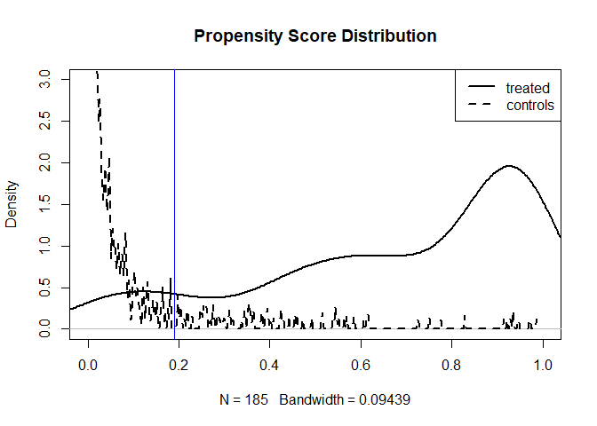

```r
pscore <- glm(nsw~age+educ+black+hisp+married+re74+re75+u74+u75,data=nsw.o,family="binomial"(link=logit))

plot(density(pscore$fit[nsw.o$nsw==1]), lwd=2, main="Propensity Score Distribution", ylim=c(0,3), xlim=c(0,1))
abline(v=0.19, col="blue")
lines(density(pscore$fit[nsw.o$nsw==0]), lwd=2, lty=2)
legend("topright", legend=c("treated","controls"), lty=c(1,2), lwd=2)
```

Look at the distributions above. Note how for individuals in the control group, the density of propensity scores close to 0 shoots up asymptotically. This is a natural consequence of the extreme group imbalance we noted earlier, which in this case causes our regression to overwhelmingly favor low propensity scores.

The blue line marks the propensity score at which the density of treated individuals overtakes that of the control. If we remove all data points below this line (aka, scores below 0.19), we are essentially cleaning out our dataset of anomalous data points and solving the class imbalance issue. After cleaning out the irrelevant points, we can now perform our matching procedure by *only* calculating ATT based on the propensity scores.

```r
nsw.o$ps <- pscore$fitted.values
nsw.trim <- subset(nsw.o, nsw.o$ps >= 0.19)

match2 = Match(Y=nsw.trim$re78, Tr=nsw.trim$nsw, X=nsw.trim[,c("ps")],exact=c(FALSE),estimand="ATT",BiasAdjust=TRUE)
summary(match2)
```

```
##
## Estimate...  2679.5
## AI SE......  1636.3
## T-stat.....  1.6375
## p.val......  0.10152
##
## Original number of observations..............  249
## Original number of treated obs...............  165
## Matched number of observations...............  165
## Matched number of observations  (unweighted).  178
##
## Number of obs dropped by 'exact' or 'caliper'  0
```

So by only matching with propensity scores, we were able to reproduce our positive ATT from the earlier matching within the same order of magnitude. Our p-value is also just above the 10% significant level.

Another option is to use our previous matching covariates again now that we have trimmed the dataset. Perhaps now that we can search a more relevant subspace of the covariate domain, we will be able to see notable improvements:

```r
varnames = c("age","educ","black","hisp","married","re74","re75","u74","u75")
exactmatch = c(FALSE,FALSE,TRUE,TRUE,TRUE,FALSE,FALSE,TRUE,TRUE)
X = nsw.trim[,varnames]

match3 = Match(Y=nsw.trim$re78, Tr=nsw.trim$nsw, X=X,exact=exactmatch,estimand="ATT",BiasAdjust=TRUE)
summary(match3)
```

```
##
## Estimate...  3445.5
## AI SE......  1764.8
## T-stat.....  1.9523
## p.val......  0.050898
##
## Original number of observations..............  249
## Original number of treated obs...............  165
## Matched number of observations...............  160
## Matched number of observations  (unweighted).  192
##
## Number of obs dropped by 'exact' or 'caliper'  5
```

In conclusion, it is important to realize that Selection on Observables is not a panacea against the inherent shortcomings of observational samples. Smith, Petra, Jeffrey, and Todd explored some criticisms of these techniques in their paper *Does matching overcome LaLonde’s critique of nonexperimental estimators?* (2005). Nevertheless, Selection on Observables is an essential tool whenever one must perform causal inference, and I hope that this demonstration provided a helpful review of some proven techniques.